# Principios y Prácticas de SEM y MLM (5ed)

Tema 1.2 Modelos de Regresión Lineal

Author

Efraín García Sánchez

Published

August 5, 2026

# Práctica

## Preparar el ambiente de trabajo

```r
# instalar los paquetes
# install.packages("tidyverse")
# install.packages("car")
# install.packages("sjPlot")
# install.packages("sjmisc")

# Cargar los paquetes
library(tidyverse)
library(car)
library(sjPlot)
library(sjmisc)
```

## Importar los datos

```r
data <- haven::read_sav(
  here::here("data",
             "northampton_student_health_data_package",
             "northampton_student_health_labelled.sav"))

dplyr::glimpse(data)
```

```
Rows: 590
Columns: 61
$ id                             <dbl> 1, 2, 3, 4, 5, 6, 7, 8, 9, 10, 11, 12, …
$ age_group                      <dbl+lbl> 1, 1, 1, 1, 1, 1, 2, 4, 1, 1, 1, 1,…
$ gender                         <dbl+lbl> 2, 1, 1, 1, 1, 2, 1, 1, 2, 2, 2, 2,…
$ sexual_orientation             <dbl+lbl> 1, 2, 1, 3, 1, 1, 1, 1, 1, 1, 1, 1,…
$ ethnicity                      <dbl+lbl> 1, 1, 1, 2, 1, 3, 1, 1, 1, 3, 1, 1,…
$ study_mode                     <dbl+lbl> 1, 1, 1, 1, 1, 1, 1, 2, 1, 1, 1, 1,…
$ study_level                    <dbl+lbl> 3, 3, 3, 3, 2, 6, 4, 3, 1, 2, 1, 1,…
$ living_situation               <dbl+lbl> 1, 2, 1, 3, 2, 4, 3, 3, 1, 2, 4, 1,…
$ phys_health                    <dbl+lbl> 3, 4, 4, 3, 4, 5, 5, 1, 4, 4, 4, 5,…
$ ment_health                    <dbl+lbl> 4, 3, 2, 4, 3, 3, 2, 1, 4, 4, 3, 5,…
$ social_connect                 <dbl+lbl> 4, 3, 1, 1, 2, 3, 2, 4, 4, 3, 3, 3,…
$ sitting_weekday_hours          <dbl> 8, 5, 7, 9, NA, 5, 11, 13, 6, 5, 12, 6,…
$ sleep_quality                  <dbl> 8, 7, 4, 7, 2, 5, 3, 8, 7, 2, 9, 7, 3, …
```

[output cut: 48 more lines]

## Pregunta de Investigación y Variables

### ¿cómo se asocia la actividad física y el consumo de alcohol con la salud mental auto-reportada?

```r
ment_health       # "In general, how would you rate your mental health?"
pa_activity_level # "how many days 30 minutes or more of physical activity?"
alcohol_freq      # "How often do you have a drink containing alcohol?"
```

## Explorar los datos: `psych::describe()`

```r
data |>
  select(ment_health, pa_activity_level, alcohol_freq, gender, age_group, ethnicity) |>
  psych::describe()
```

|  | vars | n | mean | sd | median | trimmed | mad | min | max | range | skew | kurtosis | se |
| --- | --- | --- | --- | --- | --- | --- | --- | --- | --- | --- | --- | --- | --- |
| ment_health | 1 | 590 | 3.447458 | 1.0536308 | 4 | 3.491525 | 1.4826 | 1 | 5 | 4 | -0.38341303 | -0.4028624 | 0.04337729 |
| pa_activity_level | 2 | 590 | 1.179661 | 0.5984643 | 1 | 1.224576 | 0.0000 | 0 | 2 | 2 | -0.08795511 | -0.4033747 | 0.02463838 |
| alcohol_freq | 3 | 590 | 1.484746 | 1.7015736 | 1 | 1.239407 | 1.4826 | 0 | 7 | 7 | 0.93534560 | -0.2941042 | 0.07005268 |
| gender | 4 | 590 | 1.355932 | 0.5547361 | 1 | 1.277542 | 0.0000 | 1 | 4 | 3 | 1.44811747 | 2.1026843 | 0.02283812 |
| age_group | 5 | 590 | 1.740678 | 0.9077330 | 2 | 1.591102 | 1.4826 | 1 | 6 | 5 | 1.28000042 | 1.4646418 | 0.03737078 |
| ethnicity | 6 | 590 | 2.654237 | 1.6805410 | 3 | 2.544492 | 1.4826 | 1 | 13 | 12 | 1.81835578 | 7.8735837 | 0.06918678 |

## Preparar los datos `data wrangling`

- Transformar y recodificar variables

```r
data <- data |>
  mutate(# creo variable dummy para género (Female vs Male)
         gender_female = case_when(gender == 1 ~ 1, # Female
                                   gender == 2 ~ 0, # Male
                                   .default = NULL),
         # creo una variable de etnia para los grupos más grandes
         ethnicity_cat = case_when(ethnicity == 1 ~ "White",
                                 ethnicity == 3 ~ "Black",
                                 ethnicity == 4 ~ "Asian",
                                 TRUE ~ NA_character_),
         # ordeno la variable de etnia en niveles (White es la referencia)
         ethnicity_cat = factor(ethnicity_cat,
                                levels = c("White", "Black", "Asian")),
         # Creo una variable dummy para ver diferencias con White
         ethnicity_black = ifelse(test = ethnicity_cat == "Black",
                                  yes = 1, no = 0),
         ethnicity_asian = ifelse(test = ethnicity_cat == "Asian",
                                  yes = 1, no = 0))
```

## Verificar que ha salido bien

```r
data |>
  select(gender, gender_female,
         ethnicity, ethnicity_cat,
         ethnicity_black, ethnicity_asian) |>
  tail(n = 10)
```

| gender | gender_female | ethnicity | ethnicity_cat | ethnicity_black | ethnicity_asian |
| --- | --- | --- | --- | --- | --- |
| 1 | 1 | 1 | White | 0 | 0 |
| 1 | 1 | 1 | White | 0 | 0 |
| 1 | 1 | 4 | Asian | 0 | 1 |
| 1 | 1 | 1 | White | 0 | 0 |
| 1 | 1 | 3 | Black | 1 | 0 |
| 2 | 0 | 4 | Asian | 0 | 1 |
| 1 | 1 | 1 | White | 0 | 0 |
| 2 | 0 | 4 | Asian | 0 | 1 |
| 1 | 1 | 1 | White | 0 | 0 |
| 2 | 0 | 3 | Black | 1 | 0 |

## Explorar los datos: correlaciones

```r
data |>
    dplyr::select(ment_health, pa_activity_level, alcohol_freq) |>
  correlation::correlation()
```

|  | Parameter1 | Parameter2 | r | CI | CI_low | CI_high | t | df_error | p | Method | n_Obs |
| --- | --- | --- | --- | --- | --- | --- | --- | --- | --- | --- | --- |
| 1 | ment_health | pa_activity_level | 0.09307885 | 0.95 | 0.012452045 | 0.17250314 | 2.266883 | 588 | 0.047519374 | Pearson correlation | 590 |
| 2 | ment_health | alcohol_freq | -0.13160597 | 0.95 | -0.210094438 | -0.05143198 | -3.219276 | 588 | 0.004067894 | Pearson correlation | 590 |
| 3 | pa_activity_level | alcohol_freq | 0.07938845 | 0.95 | -0.001340506 | 0.15908933 | 1.931163 | 588 | 0.053943251 | Pearson correlation | 590 |

## Explorar los datos: correlaciones (+ distribuciones)

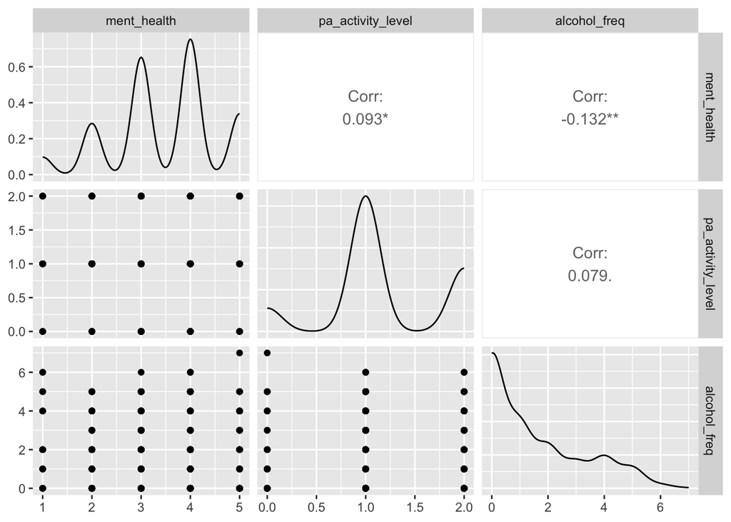

```r
data |>
  select(ment_health, pa_activity_level, alcohol_freq) |>
  GGally::ggpairs()
```

## Modelo de Regresión: El intercepto

```r
m0 <- lm(formula =  ment_health ~ 1,
         data = data)
```

:::

```r
summary(m0)
```

```
Call:
lm(formula = ment_health ~ 1, data = data)

Residuals:
    Min      1Q  Median      3Q     Max
-2.4475 -0.4475  0.5525  0.5525  1.5525

Coefficients:
            Estimate Std. Error t value Pr(>|t|)
(Intercept)  3.44746    0.04338   79.48   <2e-16 ***
---
Signif. codes:  0 '***' 0.001 '**' 0.01 '*' 0.05 '.' 0.1 ' ' 1

Residual standard error: 1.054 on 589 degrees of freedom
```

:::

:::

```r
mean(data$ment_health, na.rm = TRUE)
```

```
[1] 3.447458
```

:::

## Regresión Simple (un único predictor)

```r
m1 <- lm(ment_health ~ pa_activity_level, data = data)
```

:::

```r
parameters::parameters(m1)
```

| Parameter | Coefficient | SE | CI | CI_low | CI_high | t | df_error | p |
| --- | --- | --- | --- | --- | --- | --- | --- | --- |
| (Intercept) | 3.2541458 | 0.09560617 | 0.95 | 3.06637463 | 3.4419169 | 34.036985 | 588 | 4.017924e-141 |
| pa_activity_level | 0.1638707 | 0.07228898 | 0.95 | 0.02189465 | 0.3058467 | 2.266883 | 588 | 2.375969e-02 |

:::

## Regresión Simple (un único predictor: estandarizada)

:::

```r
parameters::standardize_parameters(m1)
```

|  | Parameter | Std_Coefficient | CI | CI_low | CI_high |
| --- | --- | --- | --- | --- | --- |
| 1 | (Intercept) | 8.019474e-16 | 0.95 | -0.08057428 | 0.08057428 |
| 2 | pa_activity_level | 9.307885e-02 | 0.95 | 0.01243620 | 0.17372150 |

:::

:::

```r
data |>
  select(ment_health, pa_activity_level) |>
  cor() |>
  round(digits = 2)
```

```
                  ment_health pa_activity_level
ment_health              1.00              0.09
pa_activity_level        0.09              1.00
```

:::

## Regresión Múltiple (más de un predictor)

```r
m2 <- lm(ment_health ~ pa_activity_level + alcohol_freq,
              data = data)

parameters::parameters(m2)
```

| Parameter | Coefficient | SE | CI | CI_low | CI_high | t | df_error | p |
| --- | --- | --- | --- | --- | --- | --- | --- | --- |
| (Intercept) | 3.35968154 | 0.09962446 | 0.95 | 3.16401776 | 3.55534532 | 33.723462 | 587 | 1.815203e-139 |
| pa_activity_level | 0.18342099 | 0.07186436 | 0.95 | 0.04227841 | 0.32456356 | 2.552322 | 587 | 1.095283e-02 |
| alcohol_freq | -0.08661315 | 0.02527558 | 0.95 | -0.13625472 | -0.03697157 | -3.426753 | 587 | 6.535728e-04 |

## Regresión Múltiple (más de un predictor)

```r
m2 <- lm(ment_health ~ pa_activity_level + alcohol_freq,
              data = data)

summary(m2)
```

```
Call:
lm(formula = ment_health ~ pa_activity_level + alcohol_freq,
    data = data)

Residuals:
    Min      1Q  Median      3Q     Max
-2.5533 -0.5431  0.2735  0.6403  2.2466

Coefficients:
                  Estimate Std. Error t value Pr(>|t|)
(Intercept)        3.35968    0.09962  33.723  < 2e-16 ***
pa_activity_level  0.18342    0.07186   2.552 0.010953 *
alcohol_freq      -0.08661    0.02528  -3.427 0.000654 ***
---
Signif. codes:  0 '***' 0.001 '**' 0.01 '*' 0.05 '.' 0.1 ' ' 1

Residual standard error: 1.04 on 587 degrees of freedom
Multiple R-squared:  0.02811,   Adjusted R-squared:  0.02479
F-statistic: 8.488 on 2 and 587 DF,  p-value: 0.0002324
```

## Regresión Múltiple (+ covariables)

```r
m3 <- lm(ment_health ~ pa_activity_level + alcohol_freq + age_group + gender_female,
              data = data)

parameters::parameters(m3)
```

| Parameter | Coefficient | SE | CI | CI_low | CI_high | t | df_error | p |
| --- | --- | --- | --- | --- | --- | --- | --- | --- |
| (Intercept) | 3.09151997 | 0.13979062 | 0.95 | 2.8169503 | 3.36608961 | 22.115361 | 568 | 1.197514e-78 |
| pa_activity_level | 0.23885205 | 0.06770235 | 0.95 | 0.1058745 | 0.37182958 | 3.527973 | 568 | 4.526267e-04 |
| alcohol_freq | -0.07422404 | 0.02381798 | 0.95 | -0.1210061 | -0.02744197 | -3.116303 | 568 | 1.923862e-03 |
| age_group | 0.29763136 | 0.04450372 | 0.95 | 0.2102194 | 0.38504331 | 6.687786 | 568 | 5.431673e-11 |
| gender_female | -0.42614023 | 0.08800158 | 0.95 | -0.5989885 | -0.25329200 | -4.842416 | 568 | 1.656024e-06 |

## Comparar el desempeño de los modelos

```r
performance::compare_performance(m0, m1, m2, m3)
```

| Name | Model | AIC | AIC_wt | AICc | AICc_wt | BIC | BIC_wt | R2 | R2_adjusted | RMSE | Sigma |
| --- | --- | --- | --- | --- | --- | --- | --- | --- | --- | --- | --- |
| m0 | lm | 1738.992 | 3.000567e-32 | 1739.013 | 3.198829e-32 | 1747.753 | 1.752416e-28 | 0.000000000 | 0.000000000 | 1.052738 | 1.0536308 |
| m1 | lm | 1735.858 | 1.437830e-31 | 1735.899 | 1.517194e-31 | 1748.999 | 9.397450e-29 | 0.008663673 | 0.006977727 | 1.048167 | 1.0499484 |
| m2 | lm | 1726.172 | 1.824011e-29 | 1726.241 | 1.898483e-29 | 1743.693 | 1.334131e-27 | 0.028105916 | 0.024794522 | 1.037838 | 1.0404867 |
| m3 | lm | 1593.824 | 1.000000e+00 | 1593.973 | 1.000000e+00 | 1619.930 | 1.000000e+00 | 0.134940745 | 0.128848779 | 0.962099 | 0.9663243 |

## Comparar los parámeteros de los modelos

```r
parameters::compare_parameters(m0, m1, m2, m3)
```

|  | Parameter | Component | Effects | Coefficient.m0 | SE.m0 | CI.m0 | CI_low.m0 | CI_high.m0 | t.m0 | df_error.m0 | p.m0 | Coefficient.m1 | SE.m1 | CI.m1 | CI_low.m1 | CI_high.m1 | t.m1 | df_error.m1 | p.m1 | Coefficient.m2 | SE.m2 | CI.m2 | CI_low.m2 | CI_high.m2 | t.m2 | df_error.m2 | p.m2 | Coefficient.m3 | SE.m3 | … |
| --- | --- | --- | --- | --- | --- | --- | --- | --- | --- | --- | --- | --- | --- | --- | --- | --- | --- | --- | --- | --- | --- | --- | --- | --- | --- | --- | --- | --- | --- | --- |
| 1 | (Intercept) | conditional | fixed | 3.447458 | 0.04337729 | 0.95 | 3.362265 | 3.532651 | 79.47609 | 589 | 4.930898e-317 | 3.2541458 | 0.09560617 | 0.95 | 3.06637463 | 3.4419169 | 34.036985 | 588 | 4.017924e-141 | 3.35968154 | 0.09962446 | 0.95 | 3.16401776 | 3.55534532 | 33.723462 | 587 | 1.815203e-139 | 3.09151997 | 0.13979062 | … |
| 2 | pa activity level | conditional | fixed | NA | NA | NA | NA | NA | NA | NA | NA | 0.1638707 | 0.07228898 | 0.95 | 0.02189465 | 0.3058467 | 2.266883 | 588 | 2.375969e-02 | 0.18342099 | 0.07186436 | 0.95 | 0.04227841 | 0.32456356 | 2.552322 | 587 | 1.095283e-02 | 0.23885205 | 0.06770235 | … |
| 3 | alcohol freq | conditional | fixed | NA | NA | NA | NA | NA | NA | NA | NA | NA | NA | NA | NA | NA | NA | NA | NA | -0.08661315 | 0.02527558 | 0.95 | -0.13625472 | -0.03697157 | -3.426753 | 587 | 6.535728e-04 | -0.07422404 | 0.02381798 | … |
| 4 | age group | conditional | fixed | NA | NA | NA | NA | NA | NA | NA | NA | NA | NA | NA | NA | NA | NA | NA | NA | NA | NA | NA | NA | NA | NA | NA | NA | 0.29763136 | 0.04450372 | … |
| 5 | gender female | conditional | fixed | NA | NA | NA | NA | NA | NA | NA | NA | NA | NA | NA | NA | NA | NA | NA | NA | NA | NA | NA | NA | NA | NA | NA | NA | -0.42614023 | 0.08800158 | … |

## Comparar modelos (parámetros y rendimiento) `sjPlot::tab_model()`

```r
sjPlot::tab_model(m0, m1, m2, m3)
```

|  | In general,how would you rate your mental health? |  |  | In general,how would you rate your mental health? |  |  | In general,how would you rate your mental health? |  |  | In general,how would you rate your mental health? |  |  |
| --- | --- | --- | --- | --- | --- | --- | --- | --- | --- | --- | --- | --- |
| Predictors | Estimates | CI | p | Estimates | CI | p | Estimates | CI | p | Estimates | CI | p |
| (Intercept) | 3.45 | 3.36 – 3.53 | **<0.001** | 3.25 | 3.07 – 3.44 | **<0.001** | 3.36 | 3.16 – 3.56 | **<0.001** | 3.09 | 2.82 – 3.37 | **<0.001** |
| On a typical week,on how many days have you done a total of 30 minutes or more of physical activity? |  |  |  | 0.16 | 0.02 – 0.31 | **0.024** | 0.18 | 0.04 – 0.32 | **0.011** | 0.24 | 0.11 – 0.37 | **<0.001** |
| How often do you have a drink containing alcohol? |  |  |  |  |  |  | -0.09 | -0.14 – -0.04 | **0.001** | -0.07 | -0.12 – -0.03 | **0.002** |
| What is your age? |  |  |  |  |  |  |  |  |  | 0.30 | 0.21 – 0.39 | **<0.001** |
| gender female |  |  |  |  |  |  |  |  |  | -0.43 | -0.60 – -0.25 | **<0.001** |
| Observations | 590 |  |  | 590 |  |  | 590 |  |  | 573 |  |  |
| R<sup>2</sup> / R<sup>2</sup> adjusted | 0.000 / 0.000 |  |  | 0.009 / 0.007 |  |  | 0.028 / 0.025 |  |  | 0.135 / 0.129 |  |  |

## Comparar modelos (parámetros y rendimiento) `sjPlot::tab_model()`

```r
sjPlot::tab_model(m0, m1, m2, m3,
                  dv.labels = c("M0. (intercepto)",
                                "M1. (PA activity)",
                                "M2. (+alcohol)",
                                "M3. (demographics)"),
                  show.ci = FALSE,
                  show.aicc = TRUE,
                  show.aic = TRUE,
                  auto.label = FALSE)
```

|  | M0. (intercepto) |  | M1. (PA activity) |  | M2. (+alcohol) |  | M3. (demographics) |  |
| --- | --- | --- | --- | --- | --- | --- | --- | --- |
| Predictors | Estimates | p | Estimates | p | Estimates | p | Estimates | p |
| (Intercept) | 3.45 | **<0.001** | 3.25 | **<0.001** | 3.36 | **<0.001** | 3.09 | **<0.001** |
| pa_activity_level |  |  | 0.16 | **0.024** | 0.18 | **0.011** | 0.24 | **<0.001** |
| alcohol_freq |  |  |  |  | -0.09 | **0.001** | -0.07 | **0.002** |
| age_group |  |  |  |  |  |  | 0.30 | **<0.001** |
| gender_female |  |  |  |  |  |  | -0.43 | **<0.001** |
| Observations | 590 |  | 590 |  | 590 |  | 573 |  |
| R<sup>2</sup> / R<sup>2</sup> adjusted | 0.000 / 0.000 |  | 0.009 / 0.007 |  | 0.028 / 0.025 |  | 0.135 / 0.129 |  |
| AIC | 1738.992 |  | 1735.858 |  | 1726.172 |  | 1593.824 |  |
| AICc | 1739.013 |  | 1735.899 |  | 1726.241 |  | 1593.973 |  |

# Ejercicio

## Ejercicio (20 minutos)

¿la salud mental auto-reportada se asocia con la etnia, el consumo de café y la calidad del sueño?

La variable dependiente será `ment_health`.

Los predictores principales serán:

```r
ethnicity_black # El grupo de referencia para etnia será `White`.
ethnicity_asian # El grupo de referencia para etnia será `White`.
caffeine_exam
sleep_quality
```

1. Explora descriptivamente las variables principales.
2. Comprueba que las variables dummy de etnia están correctamente codificadas (puedes usar `count()`)
3. Examina las asociaciones bivariadas entre salud mental, consumo de café y calidad del sueño.
4. Estima un modelo con etnia como predictor.
5. Estima un modelo **adicionando** consumo de café como predictor.
6. Estima un modelo **adicionando** calidad del sueño como predictor.
7. Estima un modelo controlando por `género` y `edad.`
8. Compara los modelos.
9. Diagnostica el modelo ajustado.
10. Visualiza los coeficientes del modelo ajustado.
11. Redacta una conclusión breve evitando interpretaciones causales fuertes.

### Reto adicional

Prueba si la calidad del sueño modera la relación entre consumo de café y salud mental.

# Soluciones

## Solución 1: explorar variables principales

```r
data |>
  select(
    ment_health,
    ethnicity_black,
    ethnicity_asian,
    caffeine_exam,
    sleep_quality,
    gender_female,
    age_group) |>
  psych::describe()
```

|  | vars | n | mean | sd | median | trimmed | mad | min | max | range | skew | kurtosis | se |
| --- | --- | --- | --- | --- | --- | --- | --- | --- | --- | --- | --- | --- | --- |
| ment_health | 1 | 590 | 3.4474576 | 1.0536308 | 4 | 3.4915254 | 1.4826 | 1 | 5 | 4 | -0.3834130 | -0.4028624 | 0.04337729 |
| ethnicity_black | 2 | 570 | 0.2771930 | 0.4480058 | 0 | 0.2214912 | 0.0000 | 0 | 1 | 1 | 0.9929164 | -1.0158901 | 0.01876490 |
| ethnicity_asian | 3 | 570 | 0.3192982 | 0.4666142 | 0 | 0.2741228 | 0.0000 | 0 | 1 | 1 | 0.7731643 | -1.4046721 | 0.01954432 |
| caffeine_exam | 4 | 590 | 3.4898305 | 2.6682561 | 3 | 3.4279661 | 4.4478 | 0 | 8 | 8 | 0.1459147 | -1.4345819 | 0.10985037 |
| sleep_quality | 5 | 590 | 6.2305085 | 2.0163385 | 6 | 6.2690678 | 2.9652 | 1 | 10 | 9 | -0.1917015 | -0.5320822 | 0.08301134 |
| gender_female | 6 | 573 | 0.6980803 | 0.4594918 | 1 | 0.7472767 | 0.0000 | 0 | 1 | 1 | -0.8606665 | -1.2614454 | 0.01919554 |
| age_group | 7 | 590 | 1.7406780 | 0.9077330 | 2 | 1.5911017 | 1.4826 | 1 | 6 | 5 | 1.2800004 | 1.4646418 | 0.03737078 |

### Qué deberían observar

- El número de casos válidos por variable.
- La presencia de valores perdidos.
- La media y desviación típica de las variables continuas.
- El rango de las variables.

### Interpretación esperada

Antes de estimar modelos, debemos comprobar que las variables tienen valores válidos, que no hay errores evidentes de codificación y que las variables continuas presentan variabilidad suficiente.

## Solución 2: comprobar las dummies de etnia

```r
data |>
  count(ethnicity_cat, ethnicity_black, ethnicity_asian)
```

| ethnicity_cat | ethnicity_black | ethnicity_asian | n |
| --- | --- | --- | --- |
| White | 0 | 0 | 230 |
| Black | 1 | 0 | 158 |
| Asian | 0 | 1 | 182 |
| NA | NA | NA | 20 |

### Qué deberían observar

- Las personas clasificadas como `White` deberían tener:
  - `ethnicity_black = 0`
  - `ethnicity_asian = 0`
- Las personas clasificadas como `Black` deberían tener:
  - `ethnicity_black = 1`
  - `ethnicity_asian = 0`
- Las personas clasificadas como `Asian` deberían tener:
  - `ethnicity_black = 0`
  - `ethnicity_asian = 1`

### Interpretación esperada

El grupo `White` funciona como grupo de referencia. Por tanto, los coeficientes de `ethnicity_black` y `ethnicity_asian` indican diferencias promedio respecto al grupo `White`.

## Solución 3: asociaciones bivariadas

```r
data |>
  select(
    ment_health,
    caffeine_exam,
    sleep_quality
  ) |>
  correlation::correlation()
```

|  | Parameter1 | Parameter2 | r | CI | CI_low | CI_high | t | df_error | p | Method | n_Obs |
| --- | --- | --- | --- | --- | --- | --- | --- | --- | --- | --- | --- |
| 1 | ment_health | caffeine_exam | -0.16867992 | 0.95 | -0.2460501 | -0.08917374 | -4.149733 | 588 | 7.640977e-05 | Pearson correlation | 590 |
| 2 | ment_health | sleep_quality | 0.40449057 | 0.95 | 0.3346983 | 0.46986941 | 10.724902 | 588 | 3.727267e-24 | Pearson correlation | 590 |
| 3 | caffeine_exam | sleep_quality | -0.05321021 | 0.95 | -0.1333578 | 0.02762882 | -1.292109 | 588 | 1.968268e-01 | Pearson correlation | 590 |

### Qué deberían observar

- La dirección de la asociación entre `caffeine_exam` y `ment_health`.
- La dirección de la asociación entre `sleep_quality` y `ment_health`.
- La fuerza relativa de ambas asociaciones.

## Solución 3: asociaciones bivariadas

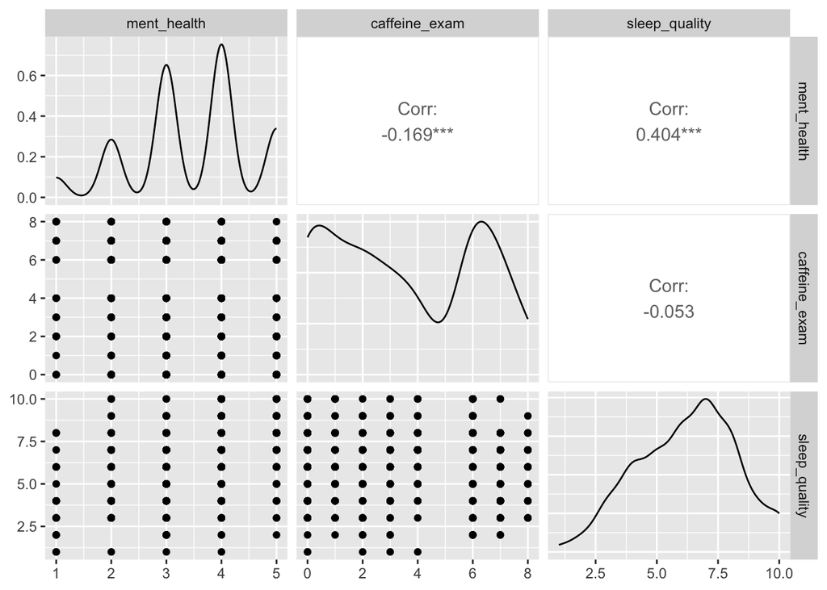

```r
data |>
  select(ment_health,
         caffeine_exam,
         sleep_quality) |>
  GGally::ggpairs()
```

### Qué deberían observar

- Si las relaciones parecen aproximadamente lineales.
- Si hay posibles casos extremos o distribuciones extrañas

### Interpretación esperada

Las correlaciones permiten una primera aproximación descriptiva, pero no controlan por otras variables. Por eso, después estimamos modelos de regresión múltiple.

## Solución 4: modelo con etnia

```r
m_ethnicity <- lm(ment_health ~ ethnicity_black + ethnicity_asian,
                  data = data)

parameters::parameters(m_ethnicity)
```

| Parameter | Coefficient | SE | CI | CI_low | CI_high | t | df_error | p |
| --- | --- | --- | --- | --- | --- | --- | --- | --- |
| (Intercept) | 3.0347826 | 0.06435449 | 0.95 | 2.9083803 | 3.1611849 | 47.157278 | 567 | 2.240749e-198 |
| ethnicity_black | 0.7563566 | 0.10084774 | 0.95 | 0.5582759 | 0.9544374 | 7.499986 | 567 | 2.477010e-13 |
| ethnicity_asian | 0.6904921 | 0.09682595 | 0.95 | 0.5003108 | 0.8806735 | 7.131271 | 567 | 3.044763e-12 |

### Interpretación de los coeficientes

- El intercepto representa el valor esperado de `ment_health` para el grupo `White`.
- El coeficiente de `ethnicity_black` representa la diferencia promedio entre el grupo `Black` y el grupo `White`.
- El coeficiente de `ethnicity_asian` representa la diferencia promedio entre el grupo `Asian` y el grupo `White`.

### Ejemplo de redacción

El modelo estimó diferencias en salud mental según etnia, usando el grupo White como referencia. Los coeficientes de `ethnicity_black` y `ethnicity_asian` indican si estos grupos presentan valores promedio de salud mental más altos o más bajos que el grupo White.

## Solución 5: modelo con consumo de café

```r
m_coffee <- lm(
  ment_health ~ ethnicity_black + ethnicity_asian + caffeine_exam,
  data = data)

parameters::parameters(m_coffee)
```

| Parameter | Coefficient | SE | CI | CI_low | CI_high | t | df_error | p |
| --- | --- | --- | --- | --- | --- | --- | --- | --- |
| (Intercept) | 3.23591124 | 0.09351516 | 0.95 | 3.05223212 | 3.41959036 | 34.603066 | 566 | 8.724489e-142 |
| ethnicity_black | 0.65572188 | 0.10583323 | 0.95 | 0.44784805 | 0.86359572 | 6.195803 | 566 | 1.116736e-09 |
| ethnicity_asian | 0.66645161 | 0.09652197 | 0.95 | 0.47686662 | 0.85603660 | 6.904662 | 566 | 1.355568e-11 |
| caffeine_exam | -0.04739712 | 0.01608504 | 0.95 | -0.07899077 | -0.01580346 | -2.946659 | 566 | 3.344561e-03 |

### Interpretación de los coeficientes

- El intercepto representa el valor esperado de `ment_health` cuando `caffeine_exam = 0`.
- El coeficiente de `caffeine_exam` indica cuánto cambia `ment_health` por cada unidad adicional de consumo de café.

### Ejemplo de redacción

El modelo estima la asociación entre consumo de café y salud mental. Un coeficiente negativo indicaría que un mayor consumo de café se asocia con valores más bajos en salud mental.

## Solución 6: modelo con calidad del sueño

```r
m_sleep <- lm(
  ment_health ~ ethnicity_black + ethnicity_asian +
    caffeine_exam + sleep_quality,
  data = data)

parameters::parameters(m_sleep)
```

| Parameter | Coefficient | SE | CI | CI_low | CI_high | t | df_error | p |
| --- | --- | --- | --- | --- | --- | --- | --- | --- |
| (Intercept) | 2.13777295 | 0.14690511 | 0.95 | 1.84922611 | 2.426319786 | 14.552067 | 565 | 5.664430e-41 |
| ethnicity_black | 0.62814994 | 0.09870780 | 0.95 | 0.43427090 | 0.822028991 | 6.363732 | 565 | 4.073800e-10 |
| ethnicity_asian | 0.44300573 | 0.09314363 | 0.95 | 0.26005567 | 0.625955786 | 4.756157 | 565 | 2.507976e-06 |
| caffeine_exam | -0.03762286 | 0.01503218 | 0.95 | -0.06714864 | -0.008097074 | -2.502821 | 565 | 1.260204e-02 |
| sleep_quality | 0.18300612 | 0.01970494 | 0.95 | 0.14430225 | 0.221709995 | 9.287324 | 565 | 3.380278e-19 |

### Interpretación de los coeficientes

- El intercepto representa el valor esperado de `ment_health` cuando `sleep_quality = 0`.
- El coeficiente de `sleep_quality` indica cuánto cambia `ment_health` por cada unidad adicional de calidad del sueño.

### Qué deberían comparar

- Si los coeficientes de etnia cambian respecto al modelo simple.
- Si el coeficiente de café cambia al incluir calidad del sueño.
- Si el coeficiente de sueño se mantiene al controlar por café y etnia.
- Qué predictores siguen siendo estadísticamente significativos.

### Ejemplo de redacción

Al incluir etnia, consumo de café y calidad del sueño en el mismo modelo, cada coeficiente representa la asociación única de ese predictor con salud mental, controlando por los demás predictores del modelo.

## Solución 7: modelo ajustado por covariables

```r
m_adjusted <- lm(
  ment_health ~ ethnicity_black + ethnicity_asian +caffeine_exam + sleep_quality + gender_female + age_group,
  data = data)

parameters::parameters(m_adjusted)
```

| Parameter | Coefficient | SE | CI | CI_low | CI_high | t | df_error | p |
| --- | --- | --- | --- | --- | --- | --- | --- | --- |
| (Intercept) | 2.09137199 | 0.16262766 | 0.95 | 1.77192210 | 2.41082188 | 12.859879 | 548 | 2.908839e-33 |
| ethnicity_black | 0.36529432 | 0.10178537 | 0.95 | 0.16535707 | 0.56523157 | 3.588869 | 548 | 3.618902e-04 |
| ethnicity_asian | 0.31549491 | 0.09198206 | 0.95 | 0.13481434 | 0.49617549 | 3.429962 | 548 | 6.491280e-04 |
| caffeine_exam | -0.05254227 | 0.01504930 | 0.95 | -0.08210363 | -0.02298090 | -3.491344 | 548 | 5.193377e-04 |
| sleep_quality | 0.18220116 | 0.01931116 | 0.95 | 0.14426821 | 0.22013412 | 9.435019 | 548 | 1.103982e-19 |
| gender_female | -0.25823445 | 0.08178415 | 0.95 | -0.41888325 | -0.09758565 | -3.157512 | 548 | 1.678787e-03 |
| age_group | 0.23901488 | 0.04412193 | 0.95 | 0.15234607 | 0.32568369 | 5.417145 | 548 | 9.080450e-08 |

### Qué deberían observar

- Si los coeficientes principales cambian al añadir `gender_female` y `age_group`.
- Si algunos predictores dejan de ser significativos.
- Si el modelo ajustado permite una interpretación más completa.

### Ejemplo de redacción

Después de ajustar por género y edad, el modelo permite estimar la asociación entre los predictores principales y salud mental manteniendo constantes estas covariables sociodemográficas.

## Solución 8: comparación de modelos

```r
performance::compare_performance(
  m_ethnicity,m_coffee,m_sleep,m_adjusted)
```

| Name | Model | AIC | AIC_wt | AICc | AICc_wt | BIC | BIC_wt | R2 | R2_adjusted | RMSE | Sigma |
| --- | --- | --- | --- | --- | --- | --- | --- | --- | --- | --- | --- |
| m_ethnicity | lm | 1594.870 | 3.226595e-38 | 1594.941 | 3.553373e-38 | 1612.252 | 1.725793e-34 | 0.1172040 | 0.1140900 | 0.9734124 | 0.9759842 |
| m_coffee | lm | 1588.192 | 9.095008e-37 | 1588.298 | 9.839475e-37 | 1609.920 | 5.538656e-34 | 0.1305420 | 0.1259336 | 0.9660308 | 0.9694384 |
| m_sleep | lm | 1509.210 | 1.287181e-19 | 1509.359 | 1.363047e-19 | 1535.283 | 8.924790e-18 | 0.2456960 | 0.2403558 | 0.8997874 | 0.9037599 |
| m_adjusted | lm | 1422.216 | 1.000000e+00 | 1422.480 | 1.000000e+00 | 1456.768 | 1.000000e+00 | 0.2925226 | 0.2847765 | 0.8589221 | 0.8643905 |

## Solución 8: comparación de modelos

```r
parameters::compare_parameters(
  m_ethnicity,m_coffee,m_sleep,m_adjusted)
```

|  | Parameter | Component | Effects | Coefficient.m_ethnicity | SE.m_ethnicity | CI.m_ethnicity | CI_low.m_ethnicity | CI_high.m_ethnicity | t.m_ethnicity | df_error.m_ethnicity | p.m_ethnicity | Coefficient.m_coffee | SE.m_coffee | CI.m_coffee | CI_low.m_coffee | CI_high.m_coffee | t.m_coffee | df_error.m_coffee | p.m_coffee | Coefficient.m_sleep | SE.m_sleep | CI.m_sleep | CI_low.m_sleep | CI_high.m_sleep | t.m_sleep | df_error.m_sleep | p.m_sleep | Coefficient.m_adjusted | SE.m_adjusted | … |
| --- | --- | --- | --- | --- | --- | --- | --- | --- | --- | --- | --- | --- | --- | --- | --- | --- | --- | --- | --- | --- | --- | --- | --- | --- | --- | --- | --- | --- | --- | --- |
| 1 | (Intercept) | conditional | fixed | 3.0347826 | 0.06435449 | 0.95 | 2.9083803 | 3.1611849 | 47.157278 | 567 | 2.240749e-198 | 3.23591124 | 0.09351516 | 0.95 | 3.05223212 | 3.41959036 | 34.603066 | 566 | 8.724489e-142 | 2.13777295 | 0.14690511 | 0.95 | 1.84922611 | 2.426319786 | 14.552067 | 565 | 5.664430e-41 | 2.09137199 | 0.16262766 | … |
| 2 | ethnicity black | conditional | fixed | 0.7563566 | 0.10084774 | 0.95 | 0.5582759 | 0.9544374 | 7.499986 | 567 | 2.477010e-13 | 0.65572188 | 0.10583323 | 0.95 | 0.44784805 | 0.86359572 | 6.195803 | 566 | 1.116736e-09 | 0.62814994 | 0.09870780 | 0.95 | 0.43427090 | 0.822028991 | 6.363732 | 565 | 4.073800e-10 | 0.36529432 | 0.10178537 | … |
| 3 | ethnicity asian | conditional | fixed | 0.6904921 | 0.09682595 | 0.95 | 0.5003108 | 0.8806735 | 7.131271 | 567 | 3.044763e-12 | 0.66645161 | 0.09652197 | 0.95 | 0.47686662 | 0.85603660 | 6.904662 | 566 | 1.355568e-11 | 0.44300573 | 0.09314363 | 0.95 | 0.26005567 | 0.625955786 | 4.756157 | 565 | 2.507976e-06 | 0.31549491 | 0.09198206 | … |
| 4 | caffeine exam | conditional | fixed | NA | NA | NA | NA | NA | NA | NA | NA | -0.04739712 | 0.01608504 | 0.95 | -0.07899077 | -0.01580346 | -2.946659 | 566 | 3.344561e-03 | -0.03762286 | 0.01503218 | 0.95 | -0.06714864 | -0.008097074 | -2.502821 | 565 | 1.260204e-02 | -0.05254227 | 0.01504930 | … |
| 5 | sleep quality | conditional | fixed | NA | NA | NA | NA | NA | NA | NA | NA | NA | NA | NA | NA | NA | NA | NA | NA | 0.18300612 | 0.01970494 | 0.95 | 0.14430225 | 0.221709995 | 9.287324 | 565 | 3.380278e-19 | 0.18220116 | 0.01931116 | … |
| 6 | gender female | conditional | fixed | NA | NA | NA | NA | NA | NA | NA | NA | NA | NA | NA | NA | NA | NA | NA | NA | NA | NA | NA | NA | NA | NA | NA | NA | -0.25823445 | 0.08178415 | … |
| 7 | age group | conditional | fixed | NA | NA | NA | NA | NA | NA | NA | NA | NA | NA | NA | NA | NA | NA | NA | NA | NA | NA | NA | NA | NA | NA | NA | NA | 0.23901488 | 0.04412193 | … |

### Qué deberían observar

- Qué modelo tiene mayor `R2`.
- Qué modelo tiene mejor AIC/BIC.
- Si el modelo ajustado mejora respecto a los modelos simples.
- Si algunos coeficientes cambian notablemente entre modelos.

### Interpretación esperada

Un modelo con más predictores suele explicar más varianza, pero eso no significa automáticamente que sea mejor. La comparación debe considerar el ajuste, la parsimonia y la interpretación teórica.

## Solución 10: tabla final de modelos

```r
sjPlot::tab_model(
  m_ethnicity,
  m_coffee,
  m_sleep,
  m_adjusted,
  dv.labels = c(
    "Etnia",
    "Café",
    "Sueño",
    "Modelo ajustado"
  ),
  show.ci = FALSE,
  show.aicc = TRUE,
  show.aic = TRUE,
  auto.label = FALSE
)
```

|  | Etnia |  | Café |  | Sueño |  | Modelo ajustado |  |
| --- | --- | --- | --- | --- | --- | --- | --- | --- |
| Predictors | Estimates | p | Estimates | p | Estimates | p | Estimates | p |
| (Intercept) | 3.03 | **<0.001** | 3.24 | **<0.001** | 2.14 | **<0.001** | 2.09 | **<0.001** |
| ethnicity_black | 0.76 | **<0.001** | 0.66 | **<0.001** | 0.63 | **<0.001** | 0.37 | **<0.001** |
| ethnicity_asian | 0.69 | **<0.001** | 0.67 | **<0.001** | 0.44 | **<0.001** | 0.32 | **0.001** |
| caffeine_exam |  |  | -0.05 | **0.003** | -0.04 | **0.013** | -0.05 | **0.001** |
| sleep_quality |  |  |  |  | 0.18 | **<0.001** | 0.18 | **<0.001** |
| gender_female |  |  |  |  |  |  | -0.26 | **0.002** |
| age_group |  |  |  |  |  |  | 0.24 | **<0.001** |
| Observations | 570 |  | 570 |  | 570 |  | 555 |  |
| R<sup>2</sup> / R<sup>2</sup> adjusted | 0.117 / 0.114 |  | 0.131 / 0.126 |  | 0.246 / 0.240 |  | 0.293 / 0.285 |  |
| AIC | 1594.870 |  | 1588.192 |  | 1509.210 |  | 1422.216 |  |
| AICc | 1594.941 |  | 1588.298 |  | 1509.359 |  | 1422.480 |  |

## Solución 10: diagnóstico del modelo ajustado

[figure not shown]

```r
performance::check_model(m_adjusted)
```

## Solución 10: diagnóstico del modelo ajustado

```r
car::vif(m_adjusted)
```

```
ethnicity_black ethnicity_asian   caffeine_exam   sleep_quality   gender_female
       1.567131        1.377200        1.198052        1.087917        1.052203
      age_group
       1.153409
```

### Qué deberían observar

- Si los residuos se distribuyen de forma aproximadamente normal.
- Si hay problemas de heterocedasticidad.
- Si hay casos influyentes.
- Si los valores de VIF sugieren colinealidad problemática (VIF > 10).

### Interpretación esperada

El diagnóstico permite evaluar si el modelo cumple razonablemente los supuestos de regresión lineal. Si hay problemas graves, los resultados deben interpretarse con cautela o modificar el modelo.

## Solución 11: visualización de coeficientes

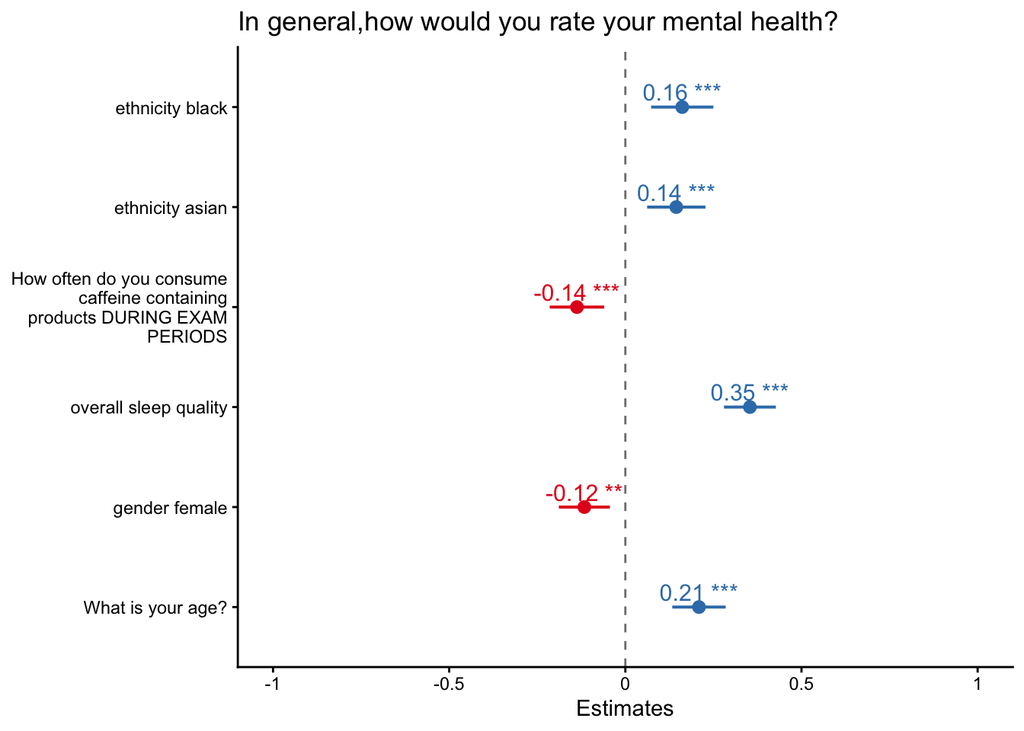

```r
sjPlot::plot_model(
  m_adjusted,
  type = "std",
  show.values = TRUE,
  show.p = TRUE
) +
  theme_classic() +
  geom_hline(
    yintercept = 0,
    linetype = 2,
    color = "gray50"
  )
```

### Interpretación esperada

El gráfico permite comparar la magnitud relativa de los predictores en escala estandarizada.

### Qué deberían observar

- Qué predictor tiene el coeficiente más grande.
- Qué predictores tienen intervalos que cruzan cero.
- Qué variables parecen tener asociaciones más consistentes con salud mental.

## Solución 12: reporte automático (orientativo)

```r
report::report(m_adjusted)
```

```
We fitted a linear model (estimated using OLS) to predict ment_health with
ethnicity_black, ethnicity_asian, caffeine_exam, sleep_quality, gender_female
and age_group (formula: ment_health ~ ethnicity_black + ethnicity_asian +
caffeine_exam + sleep_quality + gender_female + age_group). The model explains
a statistically significant and substantial proportion of variance (R2 = 0.29,
F(6, 548) = 37.76, p < .001, adj. R2 = 0.28). The model's intercept,
corresponding to ethnicity_black = 0, ethnicity_asian = 0, caffeine_exam = 0,
sleep_quality = 0, gender_female = 0 and age_group = 0, is at 2.09 (95% CI
[1.77, 2.41], t(548) = 12.86, p < .001). Within this model:

  - The effect of ethnicity black is statistically significant and positive (beta
= 0.37, 95% CI [0.17, 0.57], t(548) = 3.59, p < .001; Std. beta = 0.16, 95% CI
[0.07, 0.25])
  - The effect of ethnicity asian is statistically significant and positive (beta
= 0.32, 95% CI [0.13, 0.50], t(548) = 3.43, p < .001; Std. beta = 0.14, 95% CI
[0.06, 0.23])
  - The effect of caffeine exam is statistically significant and negative (beta =
-0.05, 95% CI [-0.08, -0.02], t(548) = -3.49, p < .001; Std. beta = -0.14, 95%
CI [-0.21, -0.06])
  - The effect of sleep quality is statistically significant and positive (beta =
0.18, 95% CI [0.14, 0.22], t(548) = 9.44, p < .001; Std. beta = 0.35, 95% CI
[0.28, 0.43])
  - The effect of gender female is statistically significant and negative (beta =
-0.26, 95% CI [-0.42, -0.10], t(548) = -3.16, p = 0.002; Std. beta = -0.12, 95%
CI [-0.19, -0.04])
  - The effect of age group is statistically significant and positive (beta =
0.24, 95% CI [0.15, 0.33], t(548) = 5.42, p < .001; Std. beta = 0.21, 95% CI
[0.13, 0.28])

Standardized parameters were obtained by fitting the model on a standardized
version of the dataset. 95% Confidence Intervals (CIs) and p-values were
computed using a Wald t-distribution approximation.
```

### Ejemplo de redacción general

Se estimó un modelo de regresión lineal para analizar si la salud mental auto-reportada se asociaba con etnia, consumo de café y calidad del sueño, ajustando por género y edad. Los resultados indican que algunos predictores se asociaron con la salud mental incluso después de controlar por las covariables incluidas en el modelo. En particular, los coeficientes permiten identificar qué variables se relacionan con valores más altos o más bajos en salud mental. Sin embargo, dado que se trata de un análisis observacional y transversal, los resultados deben interpretarse como asociaciones y no como evidencia causal.

# Reto adicional

## Solución reto: interacción entre café y sueño

```r
m_interaction <- lm(
  ment_health ~ sleep_quality * caffeine_exam +
    ethnicity_black + ethnicity_asian +
    gender_female + age_group,
  data = sjlabelled::remove_all_labels(data)
)

parameters::parameters(m_interaction)
```

| Parameter | Coefficient | SE | CI | CI_low | CI_high | t | df_error | p |
| --- | --- | --- | --- | --- | --- | --- | --- | --- |
| (Intercept) | 2.115004794 | 0.219912122 | 0.95 | 1.6830291 | 2.54698044 | 9.6174998 | 547 | 2.459667e-20 |
| sleep_quality | 0.178363922 | 0.030823181 | 0.95 | 0.1178176 | 0.23891022 | 5.7866811 | 547 | 1.209731e-08 |
| caffeine_exam | -0.059447799 | 0.045758893 | 0.95 | -0.1493325 | 0.03043687 | -1.2991529 | 547 | 1.944388e-01 |
| ethnicity_black | 0.364059426 | 0.102168599 | 0.95 | 0.1633686 | 0.56475026 | 3.5633201 | 547 | 3.981878e-04 |
| ethnicity_asian | 0.314787334 | 0.092170345 | 0.95 | 0.1337362 | 0.49583849 | 3.4152778 | 547 | 6.844613e-04 |
| gender_female | -0.257233291 | 0.082096313 | 0.95 | -0.4184959 | -0.09597066 | -3.1333111 | 547 | 1.821053e-03 |
| age_group | 0.239263031 | 0.044188498 | 0.95 | 0.1524631 | 0.32606295 | 5.4145998 | 547 | 9.210466e-08 |
| sleep_quality:caffeine_exam | 0.001109848 | 0.006944448 | 0.95 | -0.0125312 | 0.01475090 | 0.1598181 | 547 | 8.730834e-01 |

## Solución reto: interacción entre café y sueño

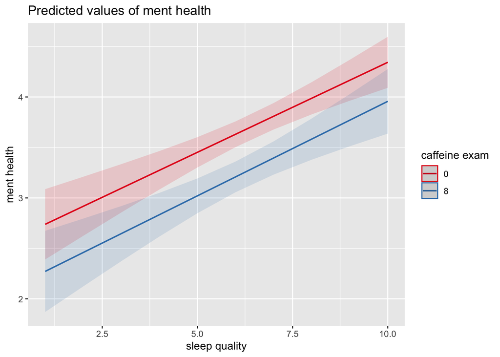

```r
sjPlot::plot_model(
  m_interaction,
  type = "int")
```

### Interpretación esperada

El término de interacción `caffeine_exam:sleep_quality` indica si la asociación entre consumo de café y salud mental cambia en función de la calidad del sueño.

### Cómo interpretar

- Si la interacción no es significativa, no hay evidencia clara de que la relación entre café y salud mental dependa de la calidad del sueño.
- Si la interacción es significativa, la asociación entre café y salud mental varía según los niveles de calidad del sueño.
- El gráfico de interacción ayuda a visualizar si la pendiente de café cambia cuando la calidad del sueño es baja, media o alta.

## Conclusión final esperada

Una conclusión adecuada debería responder a tres preguntas:

::: - ¿Qué variables parecen asociarse más claramente con salud mental? - Calidad del sueño

- ¿El modelo ajustado mejora la interpretación respecto a los modelos simples?
  - Aumento en R2, mejor ajuste y controlando por posibles confusores (etnia, edad y género)
- ¿Qué limitaciones tiene el análisis?
  - Sólo asociaciones
  - La teoría: ¿el consumo de café predice la salud mental o viceversa?

:::

## Resumen de la sesión: regresión lineal

### Ideas centrales

- La regresión lineal permite examinar cómo una variable resultado se asocia con una o más variables predictoras.
- El modelo resume una relación compleja mediante una estimación simple y útil.
- Los coeficientes indican la dirección y magnitud de la asociación entre cada predictor y el resultado.
- En modelos múltiples, cada predictor se interpreta manteniendo constantes las demás variables.
- La regresión ayuda a controlar explicaciones alternativas, pero no demuestra causalidad por sí sola.

### Buenas prácticas

- Explorar los datos antes de estimar el modelo.
- Comparar modelos simples, múltiples y ajustados.
- Evaluar el ajuste global del modelo, no solo los coeficientes individuales.
- Revisar los diagnósticos: residuos, linealidad, varianza, colinealidad y casos influyentes.
- Comunicar los resultados como asociaciones cuando el diseño no permite inferencias causales fuertes.

:::

::::

**TipImportante**

La regresión lineal no es solo una técnica para obtener coeficientes: es una herramienta para construir, comparar, diagnosticar e interpretar modelos de forma teóricamente informada y empíricamente cuidadosa.